# 第3章 資料視覺化與洞察(ggplot2)

```r
# file     : hands_on_r_03_ggplot2_notebook.Rmd
# title    : R入門實作班
# subtitle : 3.資料視覺化與洞察(ggplot2)
# author   : Ming-Chang Lee
# date     : 2026.08.09
# YouTube  : https://www.youtube.com/@alan9956
# RWEPA    : http://rwepa.blogspot.tw/
# GitHub   : https://github.com/rwepa
# Email    : alan9956@gmail.com
```

## 大綱:

- 3.1 圖表語法(aes、geom、scale、theme)
- 3.2 常用圖表：長條/折線/散點/箱型圖與選用情境
- 3.3 分面與分組比較(facet、color/fill)
- 3.4 圖表標註與故事化呈現(標題、註解、重點標示)
- 3.5 練習：產出一頁「關鍵洞察」圖表集

# 🌸 3.1 圖表語法(aes、geom、scale、theme)

## 資料視覺化（Data Visualization）的定義

- 資料視覺化（Data Visualization）是指將原始資料或分析結果，透過圖表、圖形、地圖、色彩、符號等視覺元素呈現，將複雜或大量的數據轉換成容易理解的視覺資訊，以協助人們快速發現趨勢、比較差異、了解分布、辨識異常與探索變數之間的關係。
- 簡單來說: 資料視覺化 = 將「數據」轉換成「容易看懂的圖像」，讓資料能夠被快速理解並支持決策。
- 資料視覺化 = 說故事能力 + 創造力 + 判斷力
- 輝達（NVIDIA）執行長黃仁勳他認為「說故事能力、創造力、判斷力」這3種特質難以被AI取代，持續具有高度價值。（東森財經 2026年5月27日週三 下午2:27，https://tw.stock.yahoo.com/news/ai時代讀哪科不重要-黃仁勳點名-3大能力-不可或缺-062700855.html)

## 資料視覺化七大類型

| 類型 | 目的 | 圖表 | 踩雷區 |
| --- | --- | --- | --- |
| **1. 比較 (Comparison)** | 比較大小、差異 | 長條圖、群組長條圖、水平群組長條圖 | 類別太多、沒有排序、色彩凌亂 |
| **2. 趨勢 (Trend)** | 時間變化 | 折線圖、面積圖 | 非時間資料、Y 軸刻度錯誤 |
| **3. 組成 (Composition)** | 結構比例 | 圓餅圖、100%堆疊長條圖、樹狀圖 (Treemap) | 圓餅圖使用太多類別（類別 ≤ 5）、多個圓餅圖並排比較 |
| **4. 關聯 (Relationship)** | 變數之關聯 | 散佈圖、氣泡圖 (Bubble Chart) | 點重疊嚴重 (Overplotting)、分類資料視為連續變數、同時使用大小＋顏色＋標籤 |
| **5. 分布 (Distribution)** | 異常值與資料分布 | 盒鬚圖、直方圖 | 沒有加上註解、忽略資料是否雙峰、忽略偏態與極端值 |
| **6. 地理 (Geospatial)** | 地理差異 | 填色地圖 (Filled Map)、符號地圖 (Symbol Map)、密度圖 (Density Map／熱度圖) | 數值差異很小、沒有地理關係 |
| **7. 階層型 (Hierarchy)** | 層級結構 | 樹狀圖、Sunburst、Sankey、主題式地圖 (Thematic Map／Choropleth Map) | 無結構關係、誤用於呈現時間趨勢 |

## 圖表的二大核心價值

1. 強化決策價值: 圖表不是用來展示資料，而是用來找出樣式並幫助決策。
2. 降低認知負荷: 好的視覺化，是降低思考成本，而不是增加美術效果。

## 圖表的常見錯誤

❌ 一開始就直接做圖, 沒有思考圖表的目的為何

❌ KPI 沒定義清楚

❌ 無資料驗證

❌ 只做描述分析，沒有策略

❌ 沒有加上故事線

❌ 缺少決策行動方案

## 成功的資料視覺化-4大關鍵

1.資訊 Information: 準確性, 真實性, 一致性

2.故事 Story: 資料視覺化的認同性

3.目標 Goal: 找到重要結論

4.視覺表現 Visual Form: 藝術的呈現

- 參考資料 https://informationisbeautiful.net/visualizations/what-makes-a-good-data-visualization/
- David McCandless , Knowledge Is Beautiful: Impossible Ideas, Invisible Patterns, Hidden Connections - Visualized, Oct 21, 2014.

## 資料視覺化流程

1. 視覺化目標
2. 資料準備, 資料理解, 資料整理
3. 視覺化繪圖結構
4. 視覺化結果

## 視覺化目標考量

1.資料來源 (內部/外部, 免費/付費)

2.聽眾 vs. 觀眾

3.期望結果: 高層主管 vs. 基層員工

4.確認視範化目標

- 產品銷售資料分析(產品別, 部門別, 時間別)
- 教務研究-學生休退學預警分析(院別, 系別, 學習, 休學, 退學)
- 醫學研究-疾病/藥品預測分析 (類別預測, 數值預測)
- 製造分析-生產最佳化分析
- 社會經濟資料分析 (趨勢)

5.視覺化圖表: https://datavizcatalogue.com/

## 安斯庫姆四重奏（Anscombe’s quartet)

- 安斯庫姆四重奏是四組基本的統計特性一致的數據，但由它們繪製出的圖表則截然不同。
- 每一組數據都包括了11個(x,y)點。這四組數據由統計學家弗朗西斯·安斯庫姆（Francis Anscombe）於1973年構造，他的目的是用來說明在分析數據前先**繪製圖表**的重要性，以及離群值對統計的影響之大。

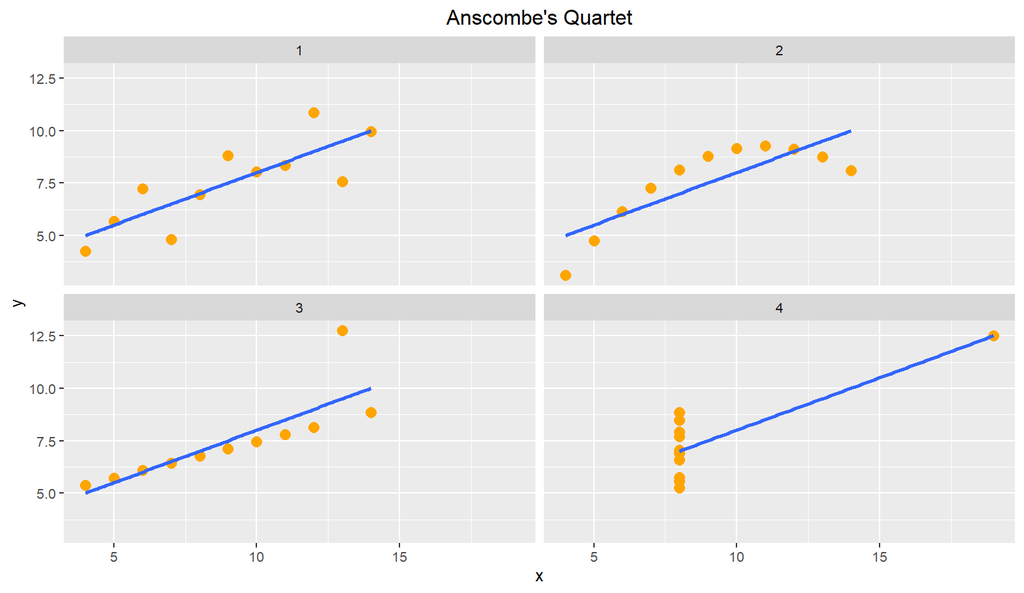

- R程式碼: https://github.com/rwepa/r_data_scientist#anscombes-quartet

## 第一個著名的視覺化案例-俄法戰爭

[figure not shown]

- 資料來源: https://en.wikipedia.org/wiki/Charles_Joseph_Minard#/media/File:Minard.png
- 繪製者: Charles Joseph Minard, a French engineer, in 1869.
- 主題: 說明拿破崙軍隊在1812年6月至1812年11月向莫斯科進軍期間所遭受的損失數量。
- 出發人數: 42.2萬
- 到達人數: 10萬
- 回國人數: 1萬

## 基本繪圖函數`plot{graphics}`

- 繪圖使用內建 `grapics`套件, 包括高階繪圖與低階繪圖.
- 高階繪圖(high-level plotting): 在圖形裝置(graphic device)上建立新的繪圖區。例：散佈圖、直線圖、長條圖、直方圖、圓形圖、盒鬚圖與3D繪圖。
- 低階繪圖(low-level plotting): 在一個已經存在的繪圖上，加上其它圖形元素。例：額外的點、線、文字與圖例等。

```r
# 繪圖函數清單, 選取第1項[Generic X-Y Plotting]
methods(plot)
```

```
##  [1] plot.acf*           plot.data.frame*    plot.decomposed.ts*
##  [4] plot.default        plot.dendrogram*    plot.density*
##  [7] plot.ecdf           plot.factor*        plot.formula*
## [10] plot.free1way*      plot.function       plot.hclust*
## [13] plot.histogram*     plot.HoltWinters*   plot.isoreg*
## [16] plot.lm*            plot.medpolish*     plot.mlm*
## [19] plot.ppr*           plot.prcomp*        plot.princomp*
## [22] plot.profile*       plot.profile.nls*   plot.R6*
## [25] plot.raster*        plot.spec*          plot.stepfun
## [28] plot.stl*           plot.table*         plot.ts
## [31] plot.tskernel*      plot.TukeyHSD*
## see '?methods' for accessing help and source code
```

```r
# 繪圖線上說明
# ?plot
```

## 散佈圖 plot

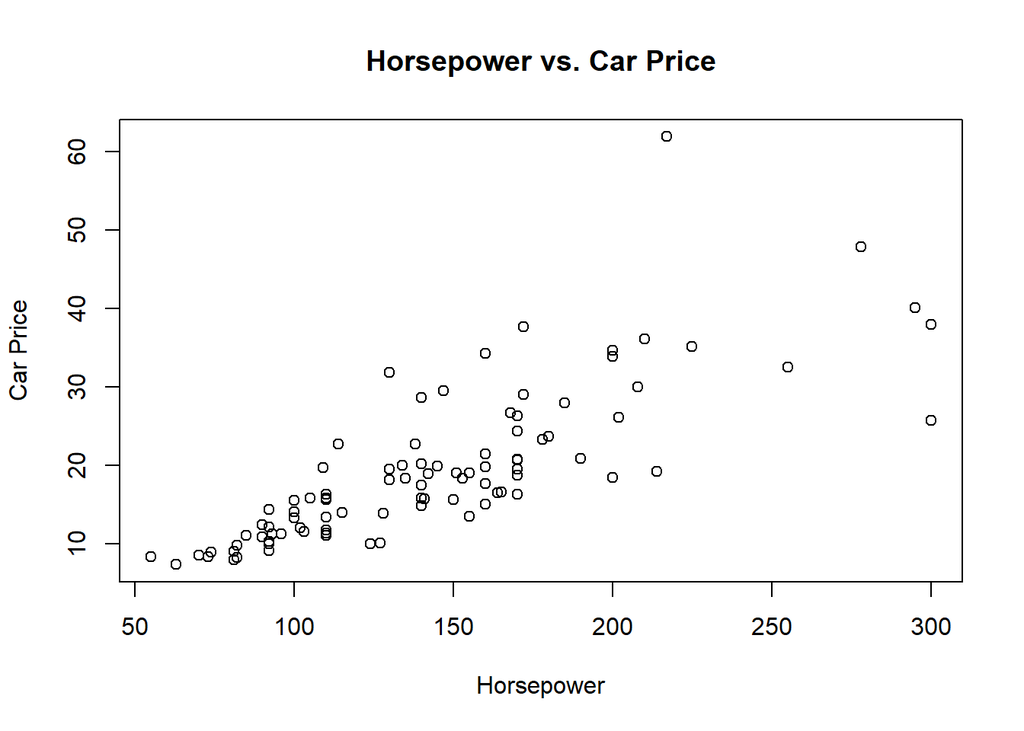

```r
data(Cars93, package = "MASS")
plot(x=Cars93$Horsepower,
     y=Cars93$Price,
     xlab="Horsepower",
     ylab="Car Price",
     main="Horsepower vs. Car Price")
```

## 散佈圖矩陣

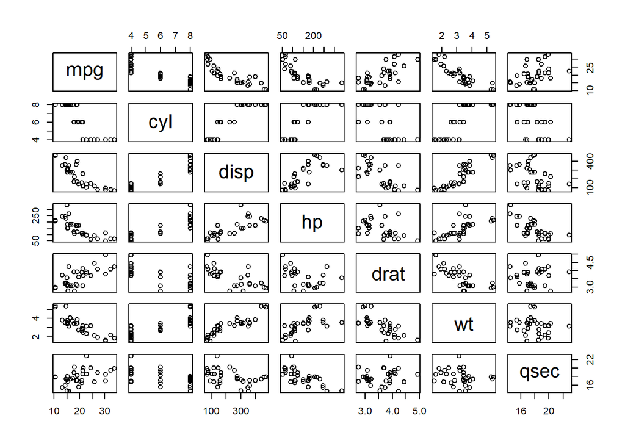

```r
data(mtcars)
pairs(mtcars[, 1:7])
```

## 客製化散佈圖矩陣

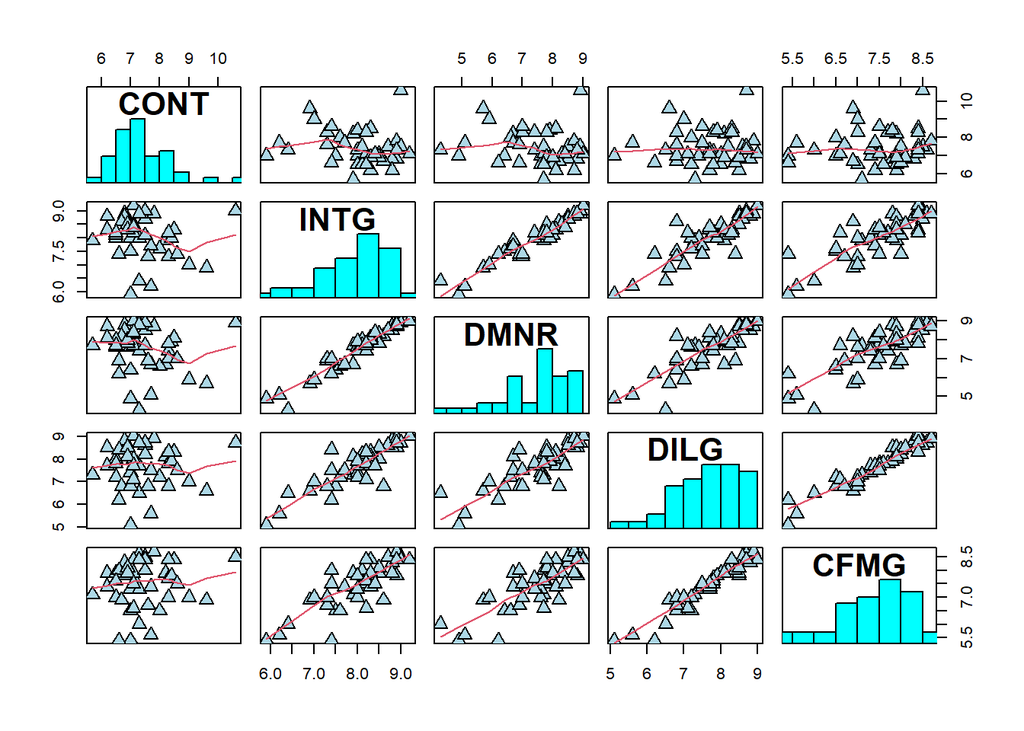

```r
panel.hist <- function(x, ...)
{
    usr <- par("usr")
    par(usr = c(usr[1:2], 0, 1.5) )
    h <- hist(x, plot = FALSE)
    breaks <- h$breaks; nB <- length(breaks)
    y <- h$counts; y <- y/max(y)
    rect(breaks[-nB], 0, breaks[-1], y, col = "cyan", ...)
}
pairs(USJudgeRatings[1:5], panel = panel.smooth,
      cex = 1.5, pch = 24, bg = "light blue", horOdd=TRUE,
      diag.panel = panel.hist, cex.labels = 2, font.labels = 2)
```

## 盒鬚圖 boxplot

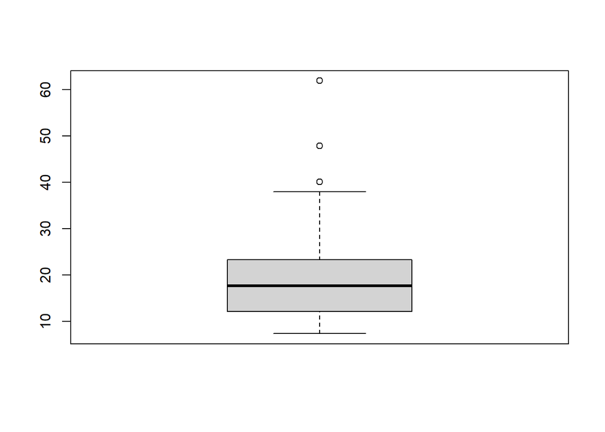

```r
boxplot(Cars93$Price)
```

```r
Cars93_Price <- boxplot(Cars93$Price)
Cars93_Price
```

```
## $stats
##      [,1]
## [1,]  7.4
## [2,] 12.2
## [3,] 17.7
## [4,] 23.3
## [5,] 38.0
##
## $n
## [1] 93
##
## $conf
##          [,1]
## [1,] 15.88139
## [2,] 19.51861
##
## $out
## [1] 40.1 47.9 61.9
##
## $group
## [1] 1 1 1
##
## $names
## [1] "1"
```

## 群組盒鬚圖 OrchardSprays 果園噴霧劑

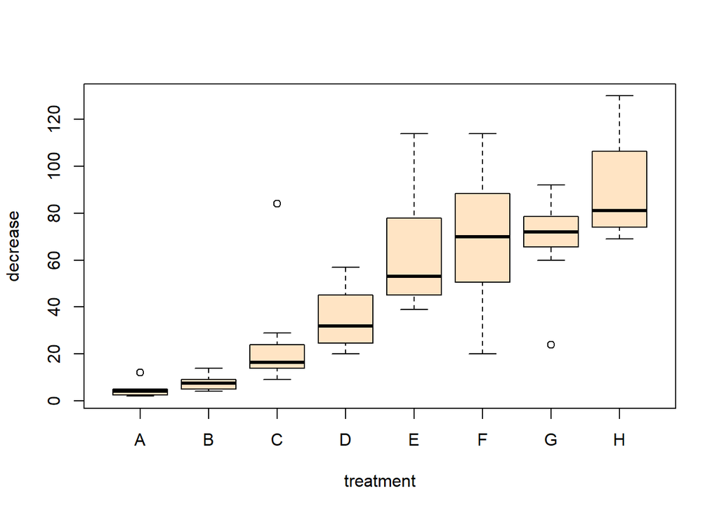

```r
boxplot(decrease ~ treatment,
        data = OrchardSprays,
        col = "bisque")
```

## 水平群組盒鬚圖

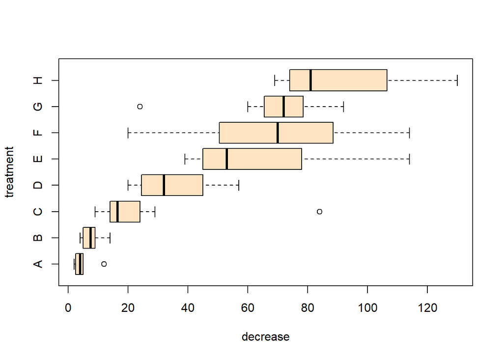

```r
boxplot(decrease ~ treatment,
        data = OrchardSprays,
        col = "bisque",
        horizontal=TRUE)
```

## 群組盒鬚圖-Y軸取log值

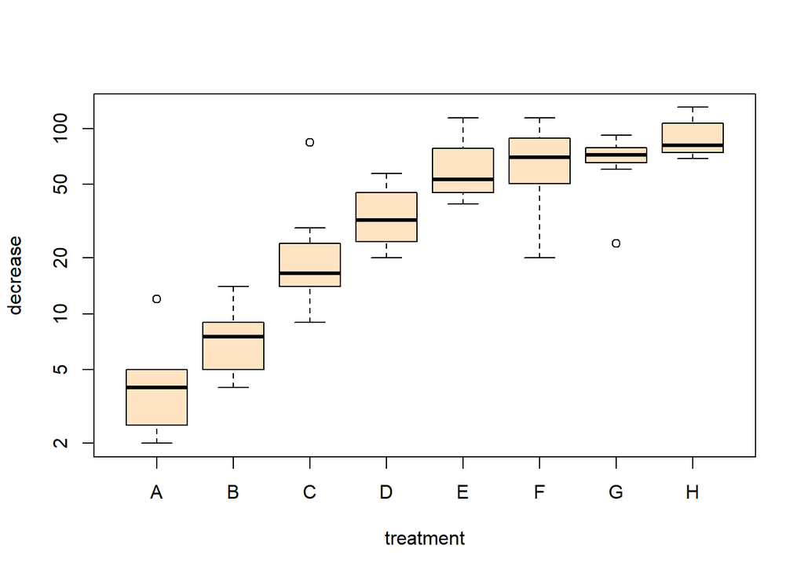

```r
boxplot(decrease ~ treatment,
        data = OrchardSprays,
        col = "bisque",
        log = "y")
```

## 長條圖 barplot

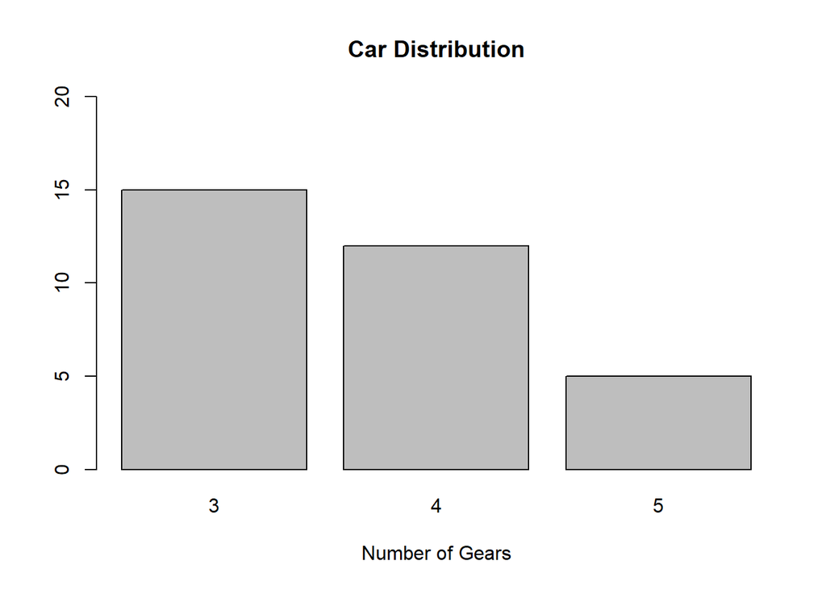

```r
counts <- table(mtcars$gear)

barplot(counts,
        main="Car Distribution",
        xlab="Number of Gears",
        ylim = c(0, 20))
```

## 直方圖 hist

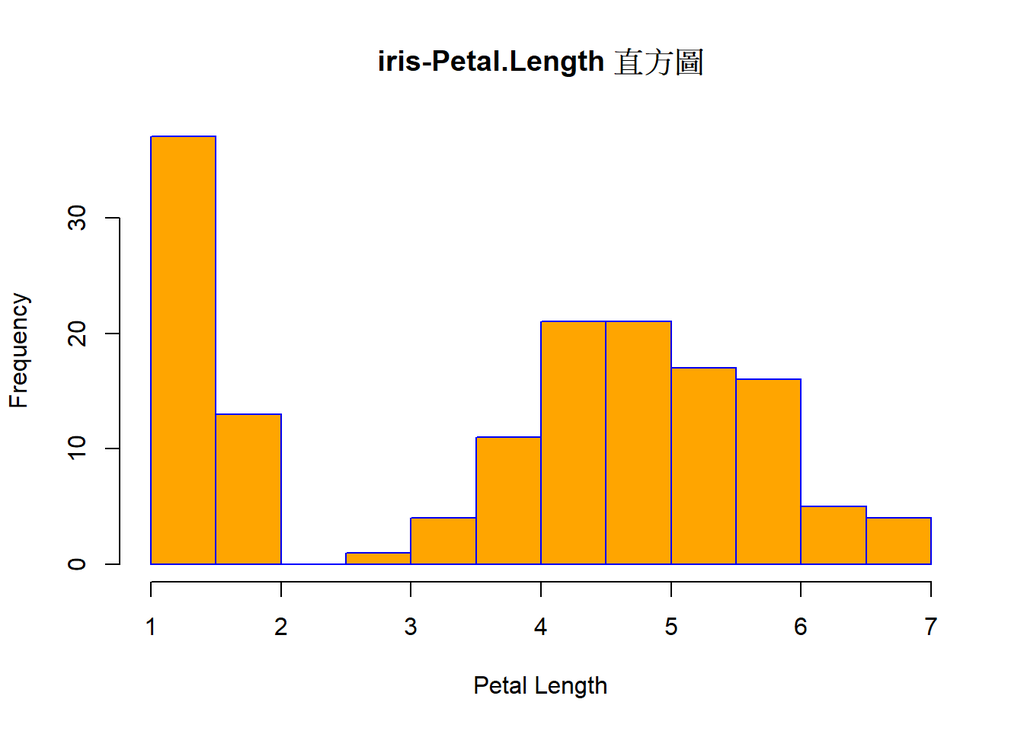

```r
hist(iris$Petal.Length,
     xlab = "Petal Length",
     col = "orange",
     border = "blue",
     main = "iris-Petal.Length 直方圖")
```

## 直方圖優化

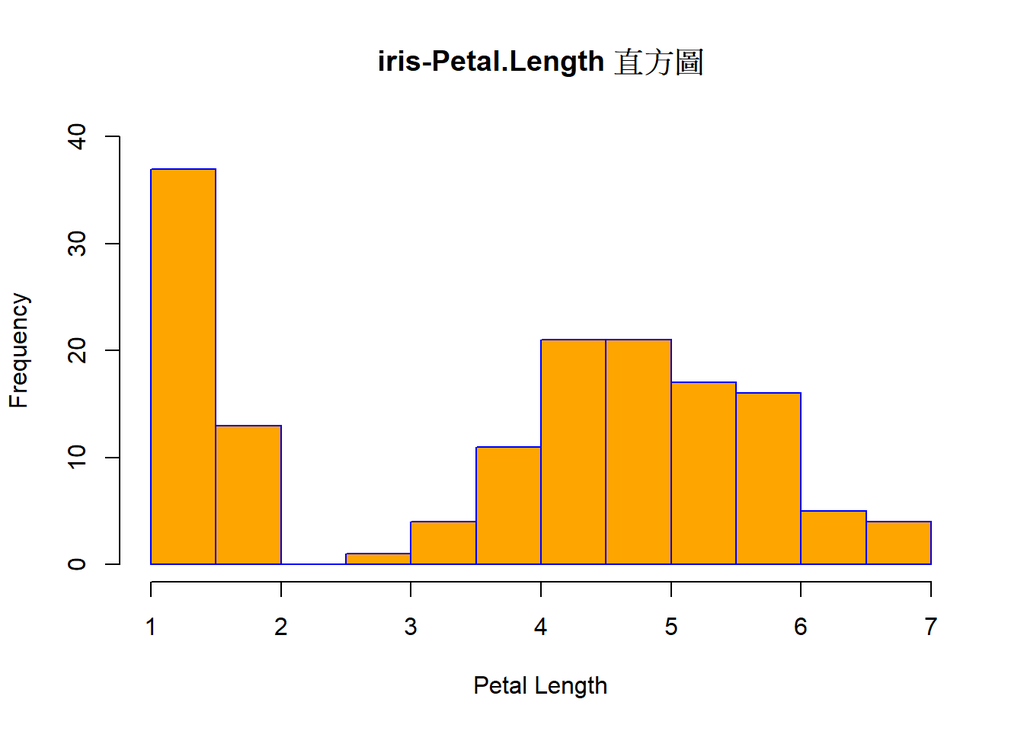

```r
hist(iris$Petal.Length,
     xlab = "Petal Length",
     col = "orange",
     border = "blue",
     main = "iris-Petal.Length 直方圖",
     ylim = c(0,40))
```

## R的圖形輸出

- http://rwepa.blogspot.com/2013/05/r.html

```r
# 將繪圖結果輸出為 PDF 檔案
data(Cars93, package = "MASS")

pdf("Cars93_xyplot.pdf")

plot(Cars93$Horsepower, Cars93$Price,
     main = "Cars93 Scatter Plot",
     xlab = "Horsepower",
     ylab = "Price",
     pch = 16,
     col = Cars93$Type)

legend("topleft",
       legend = levels(Cars93$Type),
       col = 1:length(levels(Cars93$Type)),
       pch = 16)

dev.off()
```

## 進階繪圖函數

- plot – type 參數

```r
# "p" : points
# "l" : lines
# "b" : both points and lines
# "c" : for empty points joined by lines
# "o" for overplotted points and lines
# "s" and "S" for stair steps
# "h" for histogram-like vertical lines
# "n" does not produce any points or lines (不繪圖)
```

## 加上點

```r
# ?points
# pch = {0:18} # 1: 空心圓, 16: 實心圓
```

## 加上線

```r
# ?lines
# lty值, 預設值 lty = 1
# 0  "blank"
# 1  "solid"
# 2  "dashed"
# 3  "dotted"
# 4  "dotdash"
# 5  "longdash"
# 6  "twodash"
```

## 加上區域

```r
# ?polygon
```

## 熱繪圖 image {graphics}

```r
# ?image
```

## 平行座標軸

```r
# help(parcoord, package = "MASS")
```

## 單變數繪圖

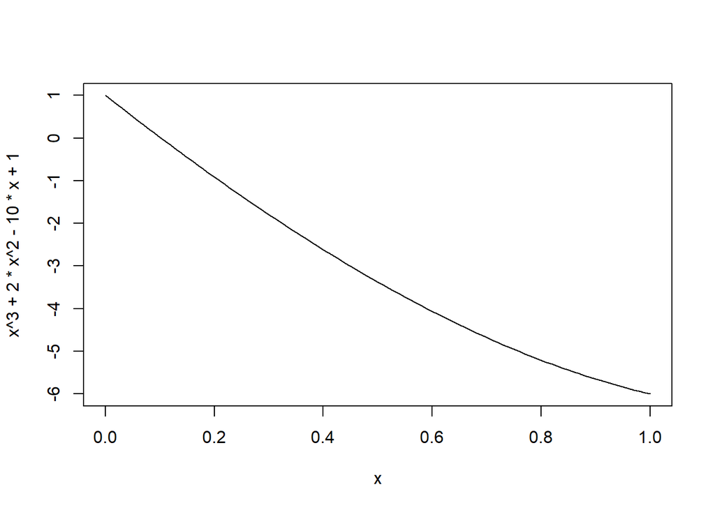

```r
# ?curve

# f(x)=x^3 + 2*x^2 - 10*x + 1
# Google -> f(x)=x^3 + 2*x^2 - 10*x + 1

curve(x^3 + 2*x^2 - 10*x + 1) # 結果怪怪的!!!
```

## GFC案例討論

```r
# https://github.com/rwepa/DataDemo/blob/master/gfc.csv

# library(readr)
# library(httr)
#
# urls <- "https://raw.githubusercontent.com/rwepa/DataDemo/refs/heads/master/gfc.csv"
#
# # Fetch content directly via GET
# response <- GET(urls)
# gfc <- read_csv(content(response, as = "raw"), show_col_types = FALSE)

# 下列程式碼適用於 Rmd 轉換至 Word
library(readr)

urls <- "https://raw.githubusercontent.com/rwepa/DataDemo/refs/heads/master/gfc.csv"

download.file(
  urls,
  destfile = "gfc.csv",
  mode = "wb",
  method = "libcurl"
)

gfc <- read_csv("gfc.csv", show_col_types = FALSE)
```

```r
head(gfc)
```

| orderdate | supplier | amount |
| --- | --- | --- |
| 2009/1/3 | 日亞 | 266 |
| 2009/1/4 | 廣達 | 123 |
| 2009/1/5 | 廣達 | 66 |
| 2009/1/6 | 日亞 | 241 |
| 2009/1/7 | 廣達 | 77 |
| 2009/1/8 | 科銳 | 50 |

```r
str(gfc)
```

```
## spc_tbl_ [293 × 3] (S3: spec_tbl_df/tbl_df/tbl/data.frame)
##  $ orderdate: chr [1:293] "2009/1/3" "2009/1/4" "2009/1/5" "2009/1/6" ...
##  $ supplier : chr [1:293] "日亞" "廣達" "廣達" "日亞" ...
##  $ amount   : num [1:293] 266 123 66 241 77 50 75 50 48 52 ...
##  - attr(*, "spec")=
##   .. cols(
##   ..   orderdate = col_character(),
##   ..   supplier = col_character(),
##   ..   amount = col_double()
##   .. )
##  - attr(*, "problems")=<pointer: 0x00000202e6dfffb0>
```

```r
summary(gfc)
```

```
##      orderdate        supplier       amount
##  Length   :293   Length   :293   Min.   : 41.0
##  N.unique :292   N.unique :  3   1st Qu.: 51.0
##  N.blank  :  0   N.blank  :  0   Median : 88.0
##  Min.nchar:  8   Min.nchar:  2   Mean   :102.4
##  Max.nchar: 10   Max.nchar:  2   3rd Qu.:119.0
##                                  Max.   :296.0
```

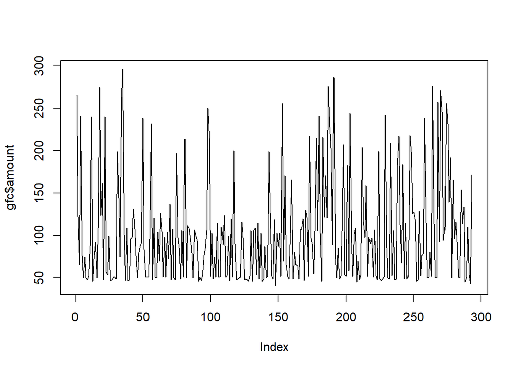

```r
# 訂購量趨勢圖
plot(gfc$amount, type = "l") # 結果似乎有進步的空間!!!
```

```r
# 優化結果: https://github.com/rwepa/DataDemo/blob/master/gfc_2_vis.R
```

## ggplot2簡介

- ggplot2 是 R 語言最常用的資料視覺化套件之一，由 Hadley Wickham 於 2005 年創立。
- ggplot2 是基於「圖形文法」（Grammar of Graphics）設計，採用圖層疊加的概念，能讓使用者把資料、美學對映（aes）與幾何圖形（geom）組合成專業圖表。
- 它的特色是把一張圖拆成不同的「圖形元件」，再利用加號運算子 (+) 將這些元件組合起來。
- Wikipedia: https://en.wikipedia.org/wiki/Ggplot2
- ggplot2 CRAN: https://cran.r-project.org/web/packages/ggplot2/index.html
- 概念: ggplot2: Create Elegant Data Visualisations Using the Grammar of Graphics (使用圖形文法建立**優雅**的資料視覺化)

## ggplot2的三大元素

- **data=**：指定視覺化的資料集。
- **aes()**：將資料中的變數對應到繪圖的美學屬性(aesthetic properties)，即是指定X、Y等對應變數。
- **geom_**：指定幾何物件的類型，例：點、線、長條圖，例：geom_point、geom_line、geom_smooth、geom_bar。
- ggplot2參考: https://r-graph-gallery.com/

## ggplot2-aes

```r
# 載入套件
library(ggplot2)

# 查閱鑽石資料集(diamonds)
# ?diamonds
```

```r
diamonds # tibble 53940*10
```

| carat | cut | color | clarity | depth | table | price | x | y | z |
| --- | --- | --- | --- | --- | --- | --- | --- | --- | --- |
| 0.23 | Ideal | E | SI2 | 61.5 | 55.0 | 326 | 3.95 | 3.98 | 2.43 |
| 0.21 | Premium | E | SI1 | 59.8 | 61.0 | 326 | 3.89 | 3.84 | 2.31 |
| 0.23 | Good | E | VS1 | 56.9 | 65.0 | 327 | 4.05 | 4.07 | 2.31 |
| 0.29 | Premium | I | VS2 | 62.4 | 58.0 | 334 | 4.20 | 4.23 | 2.63 |
| 0.31 | Good | J | SI2 | 63.3 | 58.0 | 335 | 4.34 | 4.35 | 2.75 |
| 0.24 | Very Good | J | VVS2 | 62.8 | 57.0 | 336 | 3.94 | 3.96 | 2.48 |
| 0.24 | Very Good | I | VVS1 | 62.3 | 57.0 | 336 | 3.95 | 3.98 | 2.47 |
| 0.26 | Very Good | H | SI1 | 61.9 | 55.0 | 337 | 4.07 | 4.11 | 2.53 |
| 0.22 | Fair | E | VS2 | 65.1 | 61.0 | 337 | 3.87 | 3.78 | 2.49 |
| 0.23 | Very Good | H | VS1 | 59.4 | 61.0 | 338 | 4.00 | 4.05 | 2.39 |

[output cut: 9990 more lines]

```r
# 資料結構
str(diamonds) # 53940*10
```

```
## tibble [53,940 × 10] (S3: tbl_df/tbl/data.frame)
##  $ carat  : num [1:53940] 0.23 0.21 0.23 0.29 0.31 0.24 0.24 0.26 0.22 0.23 ...
##  $ cut    : Ord.factor w/ 5 levels "Fair"<"Good"<..: 5 4 2 4 2 3 3 3 1 3 ...
##  $ color  : Ord.factor w/ 7 levels "D"<"E"<"F"<"G"<..: 2 2 2 6 7 7 6 5 2 5 ...
##  $ clarity: Ord.factor w/ 8 levels "I1"<"SI2"<"SI1"<..: 2 3 5 4 2 6 7 3 4 5 ...
##  $ depth  : num [1:53940] 61.5 59.8 56.9 62.4 63.3 62.8 62.3 61.9 65.1 59.4 ...
##  $ table  : num [1:53940] 55 61 65 58 58 57 57 55 61 61 ...
##  $ price  : int [1:53940] 326 326 327 334 335 336 336 337 337 338 ...
##  $ x      : num [1:53940] 3.95 3.89 4.05 4.2 4.34 3.94 3.95 4.07 3.87 4 ...
##  $ y      : num [1:53940] 3.98 3.84 4.07 4.23 4.35 3.96 3.98 4.11 3.78 4.05 ...
##  $ z      : num [1:53940] 2.43 2.31 2.31 2.63 2.75 2.48 2.47 2.53 2.49 2.39 ...
```

```r
# 資料摘要
summary(diamonds) # 資料沒有 NA
```

```
##      carat               cut        color        clarity          depth
##  Min.   :0.2000   Fair     : 1610   D: 6775   SI1    :13065   Min.   :43.00
##  1st Qu.:0.4000   Good     : 4906   E: 9797   VS2    :12258   1st Qu.:61.00
##  Median :0.7000   Very Good:12082   F: 9542   SI2    : 9194   Median :61.80
##  Mean   :0.7979   Premium  :13791   G:11292   VS1    : 8171   Mean   :61.75
##  3rd Qu.:1.0400   Ideal    :21551   H: 8304   VVS2   : 5066   3rd Qu.:62.50
##  Max.   :5.0100                     I: 5422   VVS1   : 3655   Max.   :79.00
##                                     J: 2808   (Other): 2531
##      table           price             x                y
##  Min.   :43.00   Min.   :  326   Min.   : 0.000   Min.   : 0.000
##  1st Qu.:56.00   1st Qu.:  950   1st Qu.: 4.710   1st Qu.: 4.720
##  Median :57.00   Median : 2401   Median : 5.700   Median : 5.710
##  Mean   :57.46   Mean   : 3933   Mean   : 5.731   Mean   : 5.735
##  3rd Qu.:59.00   3rd Qu.: 5324   3rd Qu.: 6.540   3rd Qu.: 6.540
##  Max.   :95.00   Max.   :18823   Max.   :10.740   Max.   :58.900
##
##        z
##  Min.   : 0.000
##  1st Qu.: 2.910
##  Median : 3.530
##  Mean   : 3.539
##  3rd Qu.: 4.040
##  Max.   :31.800
##
```

```r
# 設定亂數種子，使用大於或等於1整數
set.seed(168)

# 使用 sample函數自所有列數隨機抽取500筆資料
dsmall <- diamonds[sample(nrow(diamonds), 500),]

# 顯示隨機抽取500筆資料集
dsmall # 500*10
```

| carat | cut | color | clarity | depth | table | price | x | y | z |
| --- | --- | --- | --- | --- | --- | --- | --- | --- | --- |
| 0.42 | Premium | G | VS1 | 62.4 | 59.0 | 984 | 4.80 | 4.78 | 2.99 |
| 1.01 | Ideal | I | I1 | 61.6 | 56.0 | 2416 | 6.45 | 6.43 | 3.97 |
| 1.09 | Very Good | F | VS2 | 61.4 | 54.0 | 6990 | 6.66 | 6.70 | 4.10 |
| 0.31 | Good | D | SI1 | 63.9 | 54.0 | 732 | 4.30 | 4.27 | 2.74 |
| 1.01 | Ideal | G | VS1 | 59.1 | 55.0 | 7059 | 6.60 | 6.53 | 3.88 |
| 0.30 | Premium | G | VS1 | 62.5 | 59.0 | 787 | 4.32 | 4.25 | 2.68 |
| 0.58 | Ideal | J | VS2 | 60.9 | 57.0 | 1324 | 5.38 | 5.40 | 3.28 |
| 0.51 | Ideal | I | SI1 | 61.7 | 54.0 | 1000 | 5.18 | 5.19 | 3.20 |
| 1.50 | Good | H | SI1 | 61.0 | 59.0 | 9394 | 7.31 | 7.39 | 4.48 |
| 0.40 | Ideal | G | IF | 61.1 | 56.0 | 1257 | 4.76 | 4.79 | 2.92 |

[output cut: 490 more lines]

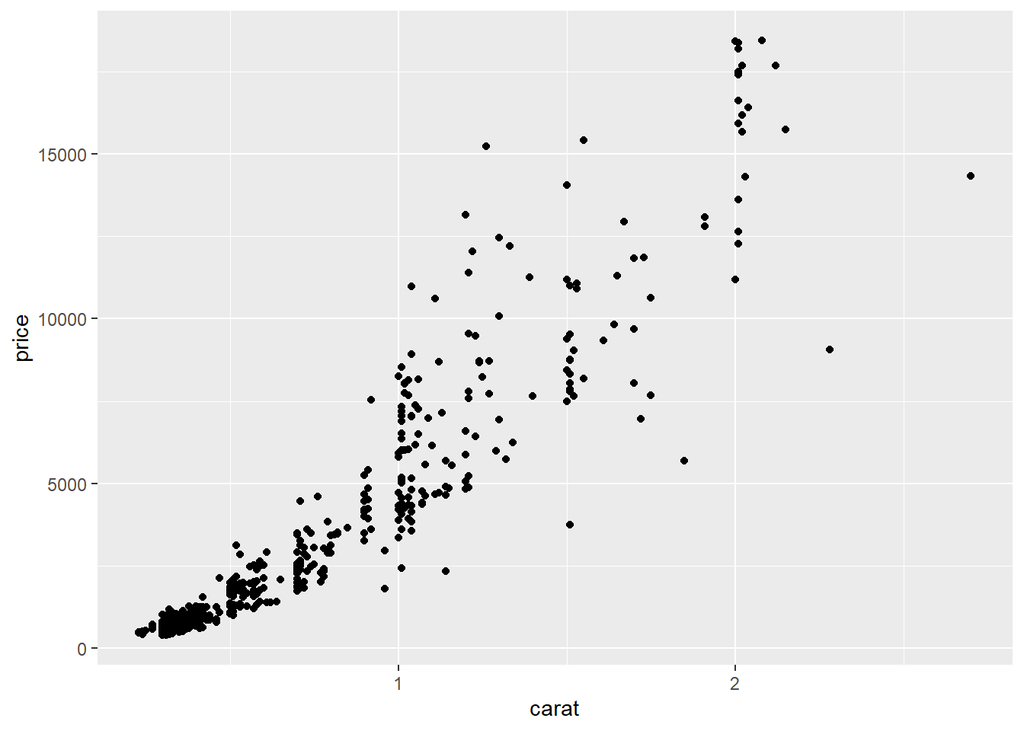

```r
# ggplot: 散佈圖(散點圖)
p <- ggplot(data=dsmall, mapping=aes(carat, price)) +
  geom_point()
p
```

## ggplot2-scale

- 控制顏色: 離散資料時常用的有 scale_color_manual() 或 scale_color_brewer()連續資料則常使用 scale_color_gradient()。

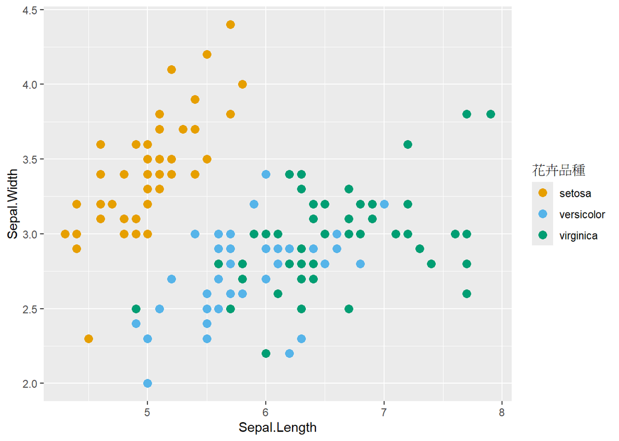

```r
library(ggplot2)

# 離散變數顏色人工設定
ggplot(iris, aes(x = Sepal.Length, y = Sepal.Width, color = Species)) +
  geom_point(size = 3) +
  scale_color_manual(
    name = "花卉品種",
    values = c("setosa" = "#E69F00", "versicolor" = "#56B4E9", "virginica" = "#009E73")
  )
```

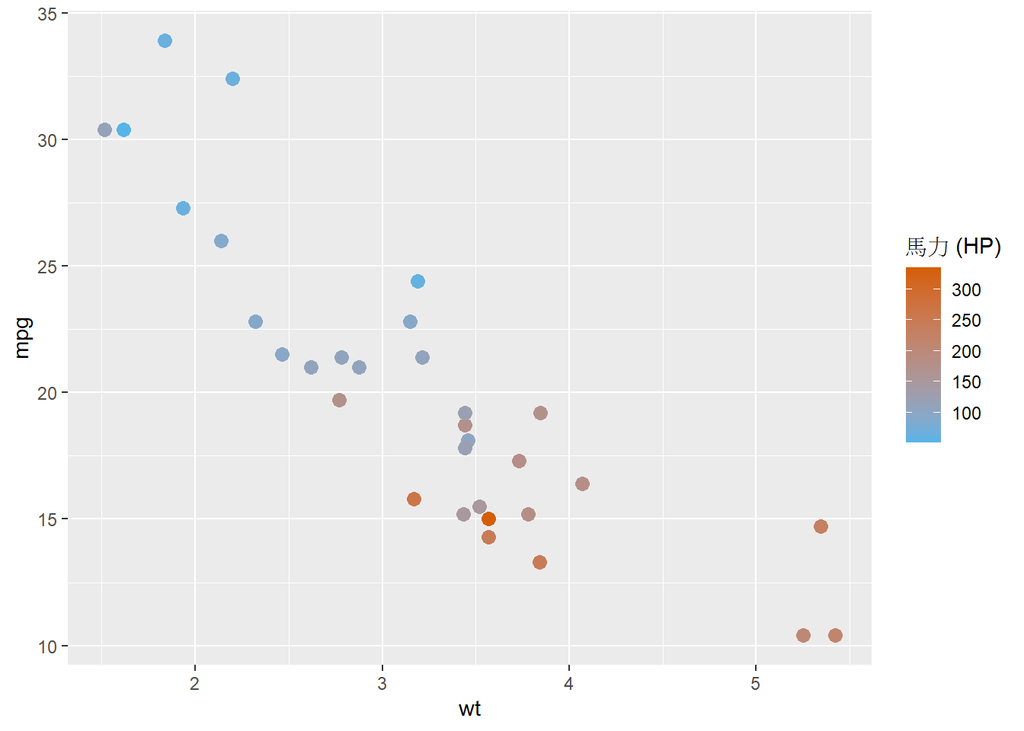

```r
# 連續變數漸層色 (Gradient)
ggplot(mtcars, aes(x = wt, y = mpg, color = hp)) +
  geom_point(size = 3) +
  scale_color_gradient(
    name = "馬力 (HP)",
    low = "#56B4E9",   # 低數值顏色
    high = "#D55E00"   # 高數值顏色
  )
```

- 控制座標軸: 連續對數/區間與離散標籤, 利用 scale_x_continuous() 可以設定軸界線、刻度標籤或進行對數轉換。

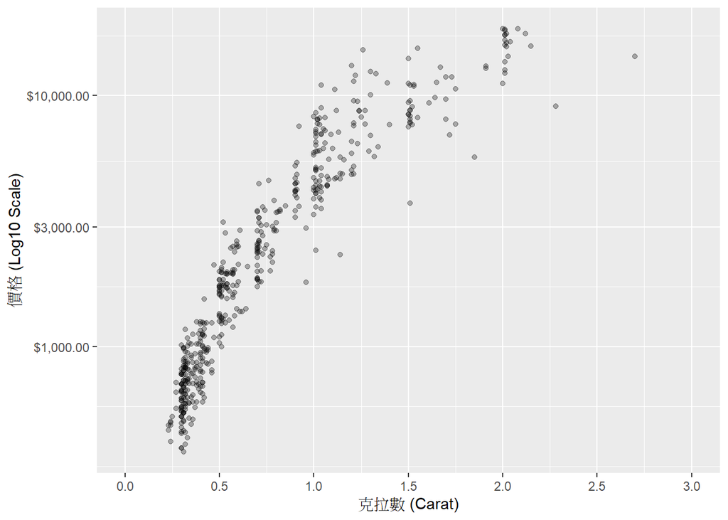

```r
# 調整 X 軸刻度與圍範，並對 Y 軸做對數轉換
ggplot(dsmall, aes(x = carat, y = price)) +
  geom_point(alpha = 0.3) +
  scale_x_continuous(
    name = "克拉數 (Carat)",
    breaks = seq(0, 5, by = 0.5), # 設定刻度位置
    limits = c(0, 3)) +           # 設定顯示範圍 (0 ~ 3)
  scale_y_log10(
    name = "價格 (Log10 Scale)",
    labels = scales::dollar)     # 搭配 scales 套件於Y軸刻度轉換成美元格式
```

## ggplot2-theme

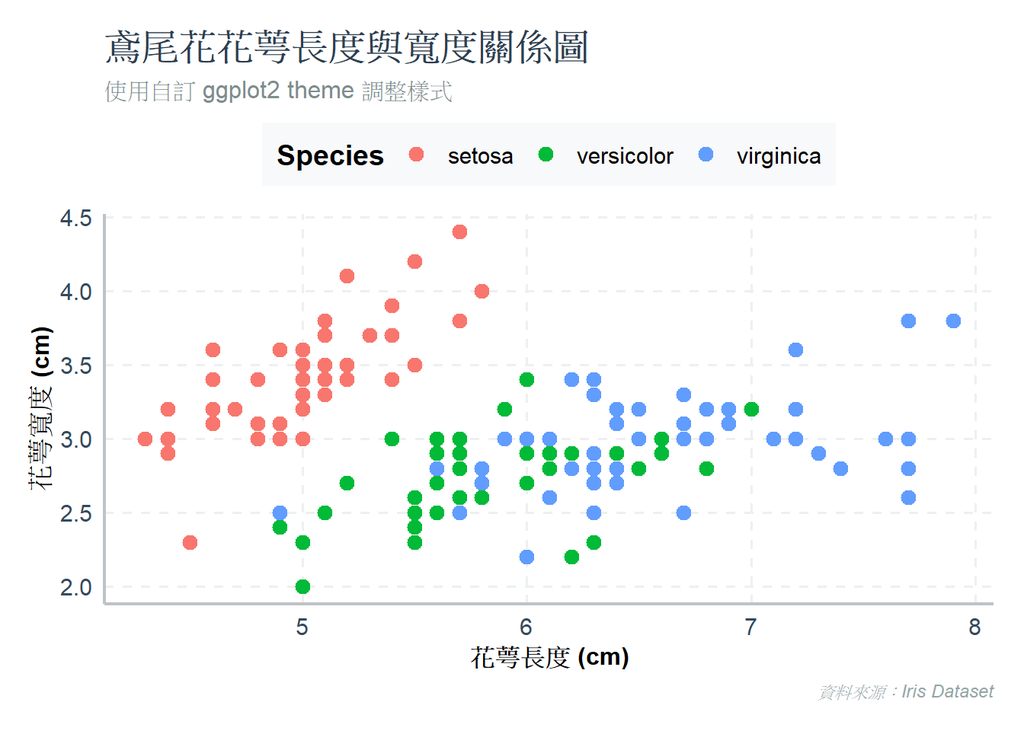

```r
ggplot(iris, aes(x = Sepal.Length, y = Sepal.Width, color = Species)) +
  geom_point(size = 3) +
  labs(
    title = "鳶尾花花萼長度與寬度關係圖",
    subtitle = "使用自訂 ggplot2 theme 調整樣式",
    x = "花萼長度 (cm)",
    y = "花萼寬度 (cm)",
    caption = "資料來源：Iris Dataset") +
  theme_minimal(base_size = 14) + # 1. 套用內建基礎主題，並統一加大基底字體
  theme(
    # --- 標題與文字 ---
    plot.title = element_text(face = "bold", size = 18, color = "#2c3e50", hjust = 0), # 主標題加粗
    plot.subtitle = element_text(size = 12, color = "#7f8c8d", margin = margin(b = 10)), # 副標題下留白
    plot.caption = element_text(size = 9, face = "italic", color = "#95a5a6"),

    # --- 座標軸 ---
    axis.title = element_text(face = "bold", size = 12),
    axis.text = element_text(color = "#34495e"),
    axis.line = element_line(color = "#bdc3c7", linewidth = 0.8), # 顯示座標軸線

    # --- 網格線 ---
    panel.grid.major = element_line(color = "#ecf0f1", linetype = "dashed"), # 主網格線改虛線
    panel.grid.minor = element_blank(), # 隱藏次網格線

    # --- 圖例 (Legend) ---
    legend.position = "top",              # 圖例擺放位置："top", "bottom", "left", "right", "none"
    legend.title = element_text(face = "bold"),
    legend.background = element_rect(fill = "#f8f9fa", color = NA), # 圖例背景色

    # --- 整體背景與邊界 ---
    plot.background = element_rect(fill = "white", color = NA),
    plot.margin = margin(t = 15, r = 15, b = 15, l = 15) # 上右下左留白 (mm)
  )
```

# 🌸 3.2 常用圖表：長條/折線/散點/箱型圖與選用情境

## 長條圖

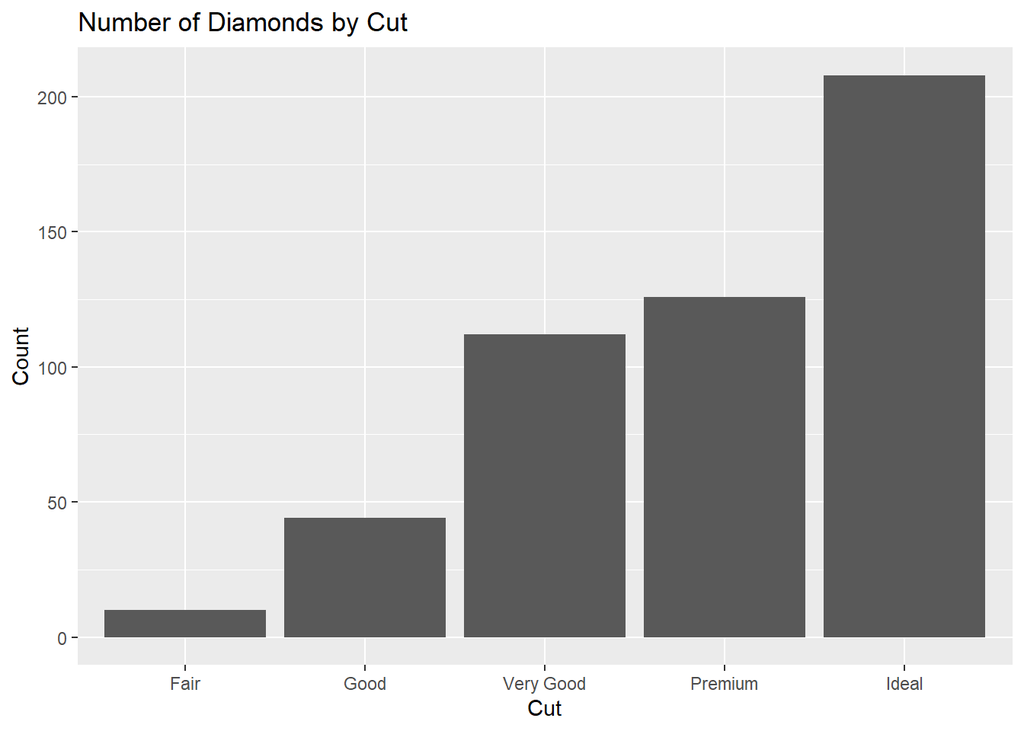

```r
# cut 各類別的長條圖
# X 軸: cut, Y 軸: 資料筆數（count）
ggplot(dsmall, aes(x = cut)) +
  geom_bar() +
  labs(
    title = "Number of Diamonds by Cut",
    x = "Cut",
    y = "Count"
  )
```

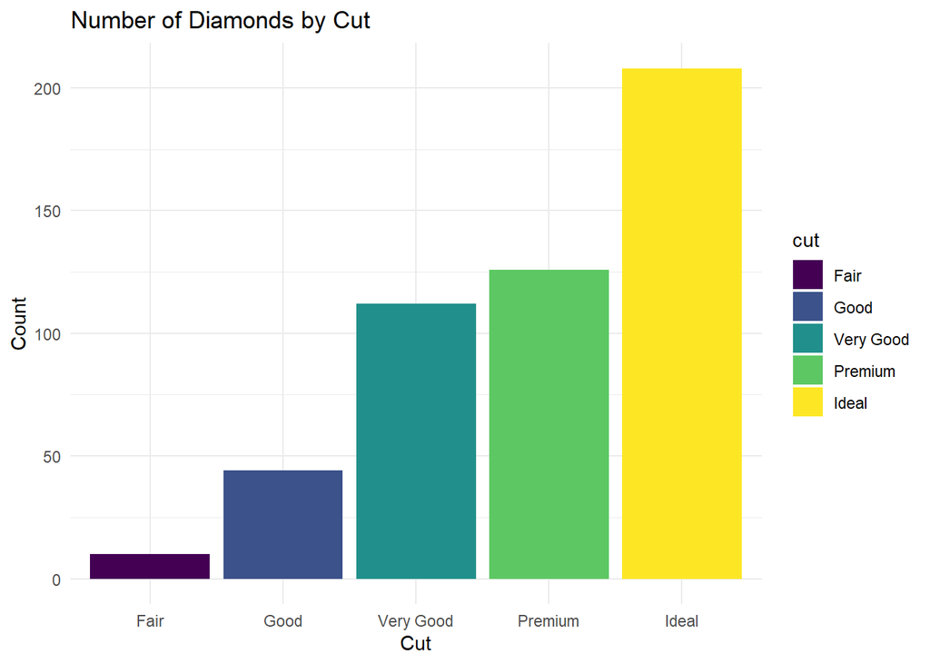

```r
# 使用 fill = cut 填滿顏色
ggplot(dsmall, aes(x = cut, fill = cut)) +
  geom_bar() +
  labs(
    title = "Number of Diamonds by Cut",
    x = "Cut",
    y = "Count"
  ) +
  theme_minimal()
```

## 補充篇-直方圖

- price 呈現右偏分布（Right-Skewed Distribution / Positive Skewness）。
- 大部分資料集中在左側，也就是較低價格區間，而右側則拖出一條很長的尾巴。
- 大多數鑽石的價格集中在相對較低的價格區間。
- 右側高價格資料相對較少。
- price 資料分布不是常態分配。
- 資料呈現 Mean > Median。

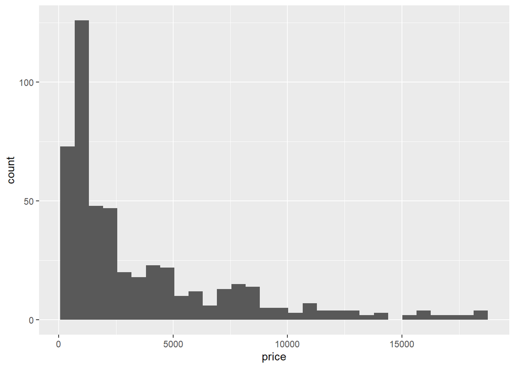

```r
ggplot(dsmall, aes(x = price)) +
  geom_histogram()
```

## 折線圖

### 美國經濟指標資料集 economics {ggplot2}

```r
# 資料來源: FRED是聯邦儲備經濟數據 (Federal Reserve Economic Data)
# 載入資料集 economics
data(economics)
```

```r
# 第１欄位為 Date 資料型別，其餘為數值。
# 資料集考慮第１個欄位為日期資料型態。
economics # 574*6
```

| date | pce | pop | psavert | uempmed | unemploy |
| --- | --- | --- | --- | --- | --- |
| 1967-07-01 | 506.7 | 198712.0 | 12.6 | 4.5 | 2944 |
| 1967-08-01 | 509.8 | 198911.0 | 12.6 | 4.7 | 2945 |
| 1967-09-01 | 515.6 | 199113.0 | 11.9 | 4.6 | 2958 |
| 1967-10-01 | 512.2 | 199311.0 | 12.9 | 4.9 | 3143 |
| 1967-11-01 | 517.4 | 199498.0 | 12.8 | 4.7 | 3066 |
| 1967-12-01 | 525.1 | 199657.0 | 11.8 | 4.8 | 3018 |
| 1968-01-01 | 530.9 | 199808.0 | 11.7 | 5.1 | 2878 |
| 1968-02-01 | 533.6 | 199920.0 | 12.3 | 4.5 | 3001 |
| 1968-03-01 | 544.3 | 200056.0 | 11.7 | 4.1 | 2877 |
| 1968-04-01 | 544.0 | 200208.0 | 12.3 | 4.6 | 2709 |

[output cut: 564 more lines]

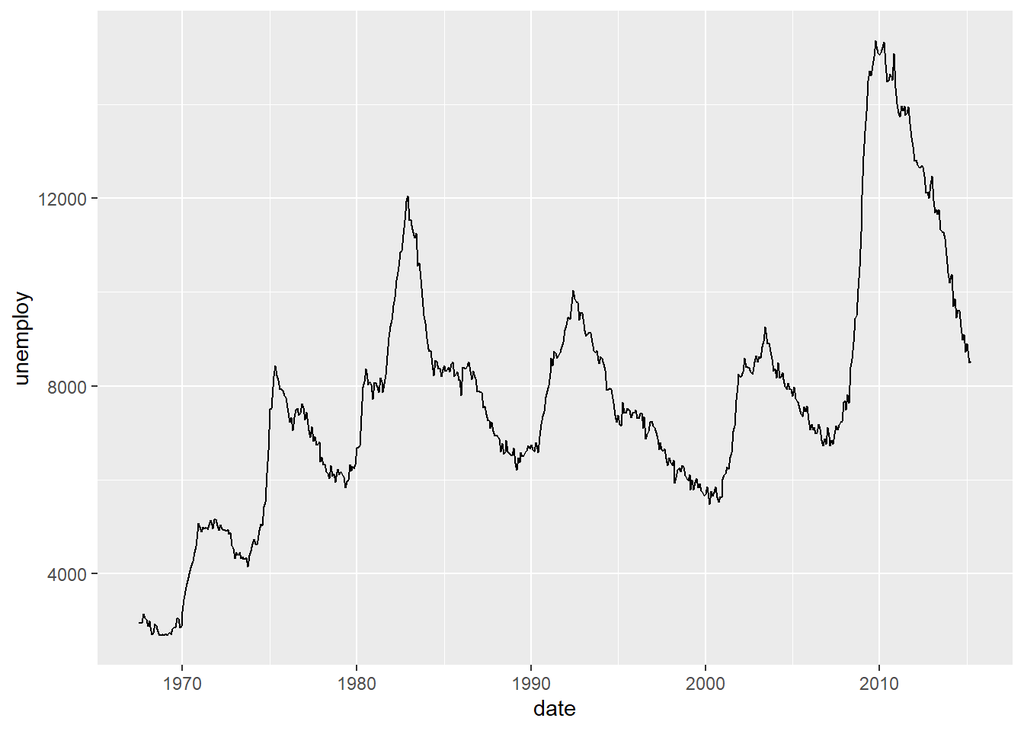

```r
# 使用 geom_line() 繪製時間序列圖（線圖）
ggplot(economics, aes(date, unemploy)) +
  geom_line()
```

### 美國經濟時間序列資料集(長資料) economics_long {ggplot2}

```r
# 載入資料集 economics_long, 此為economics 轉換為長資料(Long data)
data(economics_long)
```

```r
# 資料已經轉換為長資料，value01 表示 Min-Max Normalization，將資料轉換為０～１。
economics_long
```

| date | variable | value | value01 |
| --- | --- | --- | --- |
| 1967-07-01 | pce | 506.7 | 0.000000e+00 |
| 1967-08-01 | pce | 509.8 | 2.652497e-04 |
| 1967-09-01 | pce | 515.6 | 7.615234e-04 |
| 1967-10-01 | pce | 512.2 | 4.706043e-04 |
| 1967-11-01 | pce | 517.4 | 9.155394e-04 |
| 1967-12-01 | pce | 525.1 | 1.574385e-03 |
| 1968-01-01 | pce | 530.9 | 2.070659e-03 |
| 1968-02-01 | pce | 533.6 | 2.301683e-03 |
| 1968-03-01 | pce | 544.3 | 3.217222e-03 |
| 1968-04-01 | pce | 544.0 | 3.191553e-03 |

[output cut: 2860 more lines]

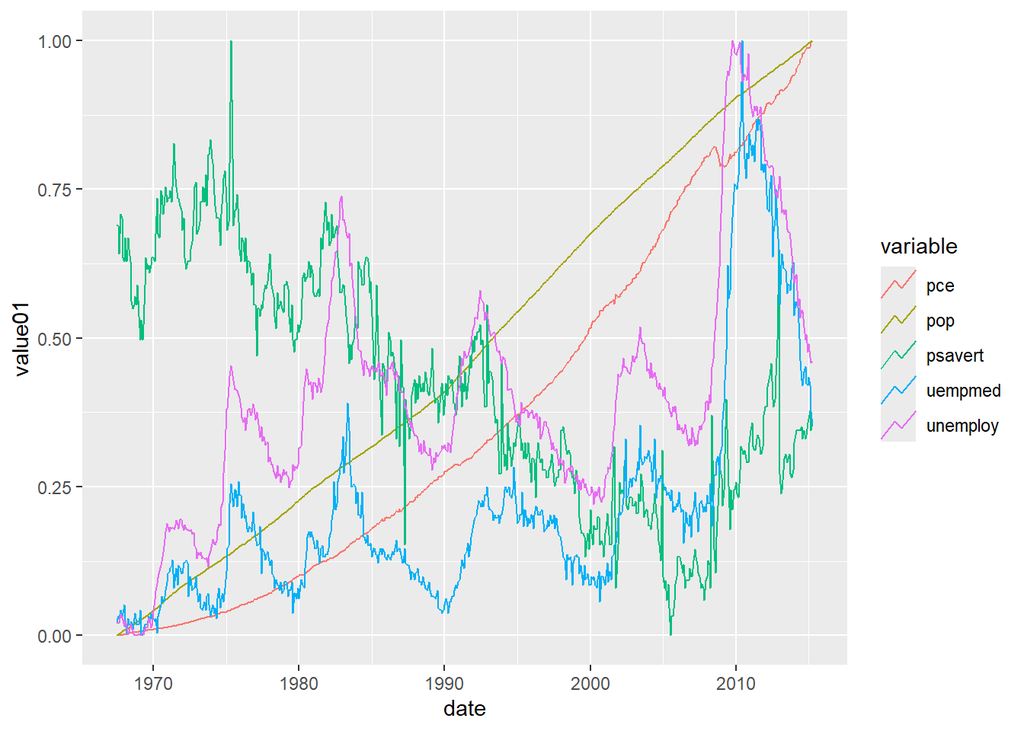

```r
# 使用 key_glyph 群組不同經濟指標
ggplot(economics_long, aes(date, value01, colour = variable)) +
  geom_line(key_glyph = "timeseries") # 圖例的圖示 (Key glyphs for legends)
```

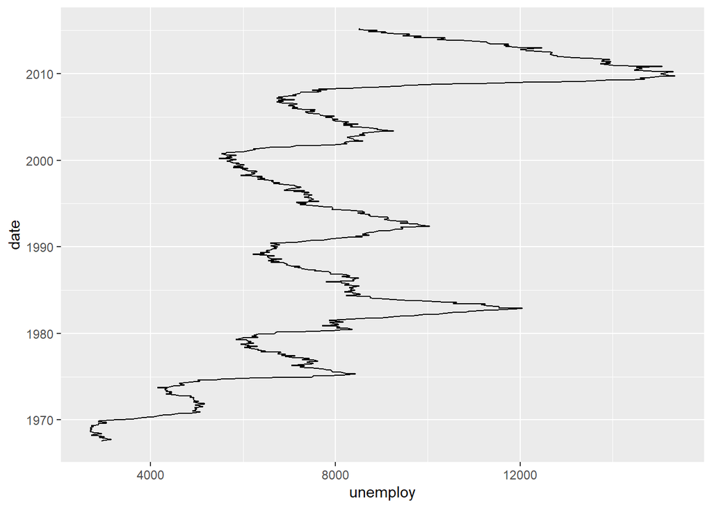

```r
# 改為垂直型時間序列圖
ggplot(economics, aes(unemploy, date)) +
  geom_line(orientation = "y")
```

### iris 折線圖

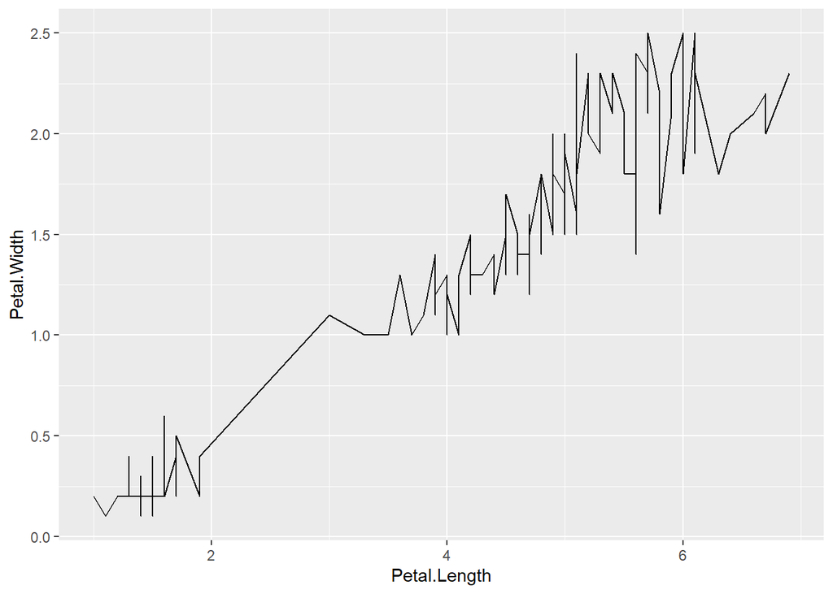

```r
# ggplot: 線圖
ggplot(iris, aes(Petal.Length, Petal.Width)) +
  geom_line()
```

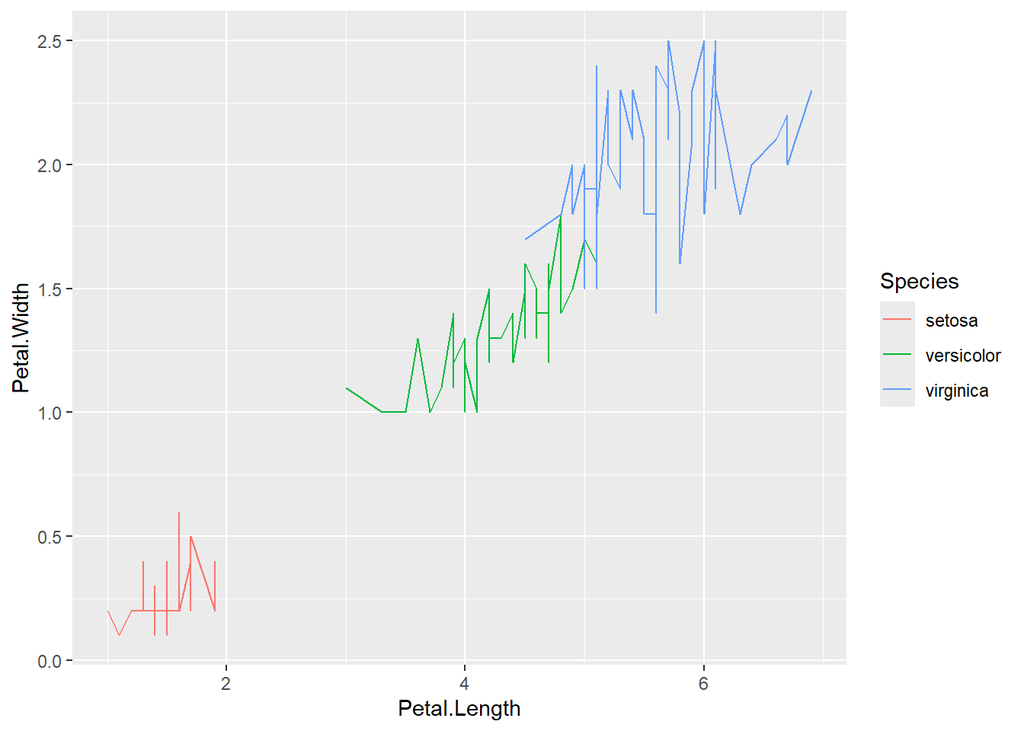

```r
# ggplot: 線圖+群組+顏色
ggplot(iris, aes(Petal.Length, Petal.Width, group=Species, color=Species)) + # group: 群組
  geom_line()
```

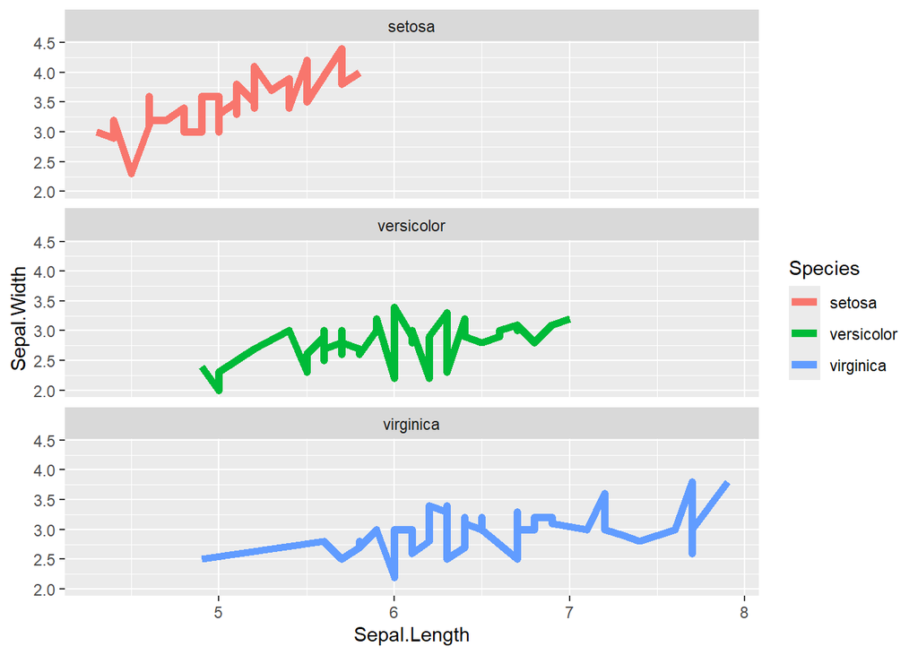

```r
# ggplot: 線圖+分面
ggplot(iris, aes(Sepal.Length, Sepal.Width)) +
  geom_line(aes(color=Species), linewidth=2) +
  facet_wrap(~Species, ncol=1)
```

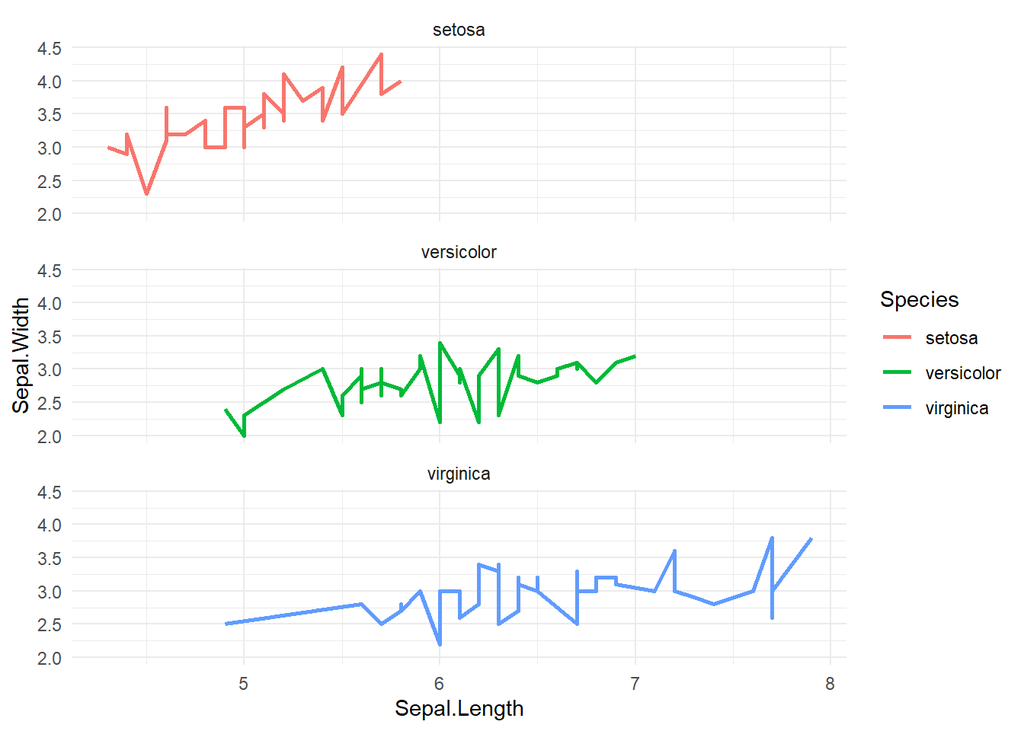

```r
# ggplot: 線圖+分面
# theme_ 設定繪圖風格，例：theme_gray、theme_bw、theme_minimal、theme_classic
# 參考`?theme_classic`
ggplot(iris, aes(Sepal.Length, Sepal.Width)) +
  geom_line(aes(color=Species), size=1) +
  facet_wrap(~Species, ncol=1) +
  theme_minimal()
```

## 散佈圖(散點圖)

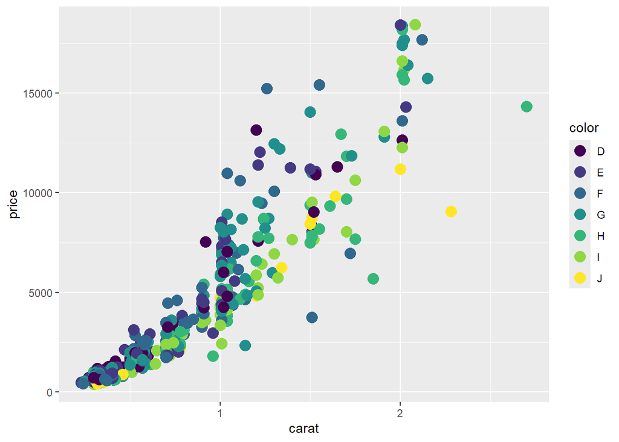

```r
# 使用 dsmall 資料集
# ggplot: 群組散佈圖
# 等號左側color表示群組參數，右側color表示變數名稱
p <- ggplot(data=dsmall, mapping=aes(carat, price, color=color)) +
  geom_point(size=4)
p
```

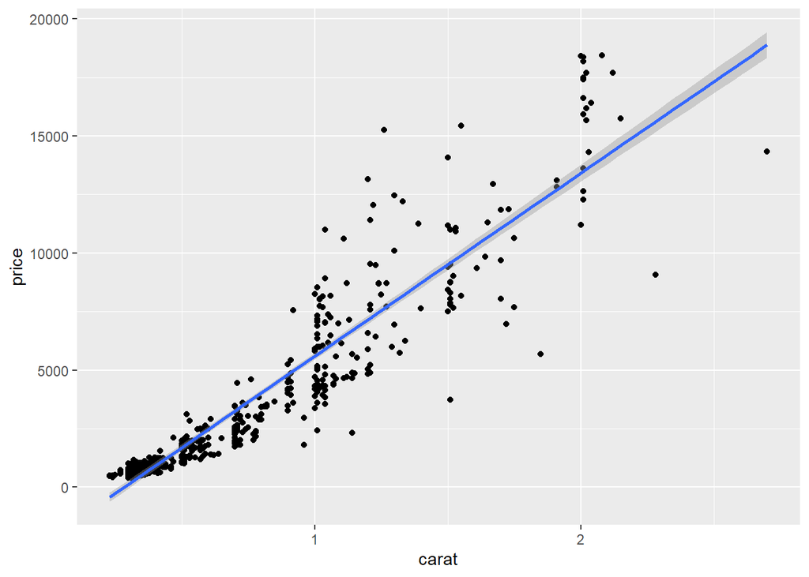

```r
# ggplot: 散佈圖 + 線性迴歸 + 95%信賴區間
p <- ggplot(dsmall, aes(carat, price)) +
  geom_point() +
  geom_smooth(method="lm")
p
```

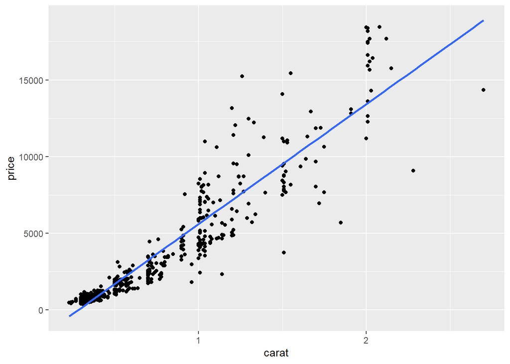

```r
# ggplot: 散佈圖 + 線性迴歸 + 不顯示信賴區間
ggplot(dsmall, aes(carat, price)) +
  geom_point() +
  geom_smooth(method="lm", formula = 'y ~ x', se=FALSE) # 省略 formula = 'y ~ x' 亦可以執行
```

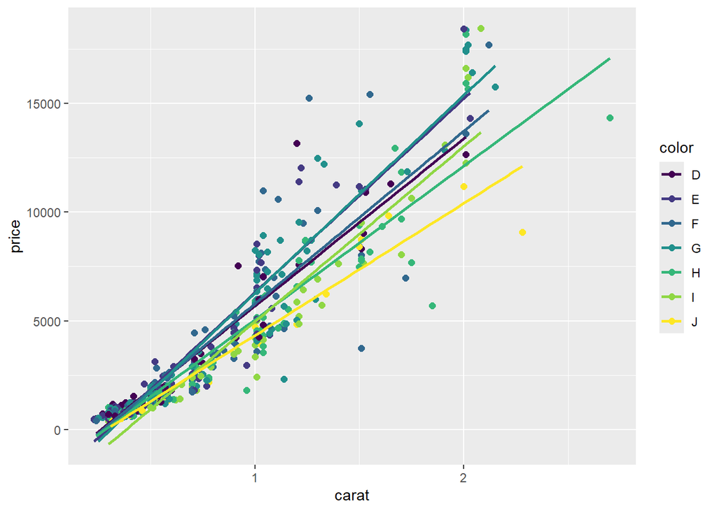

```r
# ggplot: 散佈圖 + 群組lm (lm: Linear Model 線性模型)
ggplot(dsmall, aes(carat, price, group=color)) +
  geom_point(aes(color=color), size=2) +
  geom_smooth(aes(color=color), method="lm", se=FALSE)
```